# SSF for gulls

Marie Auger-Méthé

2026-01-16

# Set up

## Packages

```r
library(here) # To simplify data sharing
library(tidyverse)
library(ggpubr) # To put plots side-by-side
library(sf) # to handle spatial object
library(amt) # to prep data for ssf (and fit simpler ssf)
library(glmmTMB)
library(terra)
library(tidyterra)
library(kableExtra)
library(modelsummary)
options(modelsummary_factory_default = 'kableExtra') # New version has tinytable default option
options(modelsummary_factory_latex = 'kableExtra')
options(modelsummary_factory_html = 'kableExtra')
library(tinytable)
library(MuMIn)
```

## Gull data

```r
gulls <- read.csv(file=file.path(here("Data/2_Gulls/Movement"),"gulls_day_notoncol.csv"))
head(gulls)
```

```
##   device_id        UTC_datetime satcount hdop Latitude Longitude final_chick
## 1    223293 2023-06-12 19:41:19        8  0.9 48.64690 -123.3360           0
## 2    223293 2023-06-12 19:56:18        7  1.0 48.64684 -123.3364           0
## 3    223293 2023-06-12 20:11:18        8  0.8 48.64682 -123.3366           0
## 4    223293 2023-06-12 20:26:18        9  0.8 48.64674 -123.3364           0
## 5    223293 2023-06-12 20:41:19        8  0.9 48.64594 -123.3364           0
## 6    223293 2023-06-13 15:26:29        6  1.5 48.64705 -123.3386           0
##   tagging_date_local release_time_local       DatetimeLocal    X_UTM   Y_UTM
## 1         2023-06-11              12:30 2023-06-12 12:41:19 475250.4 5388259
## 2         2023-06-11              12:30 2023-06-12 12:56:18 475220.6 5388253
## 3         2023-06-11              12:30 2023-06-12 13:11:18 475206.6 5388251
## 4         2023-06-11              12:30 2023-06-12 13:26:18 475218.3 5388241
## 5         2023-06-11              12:30 2023-06-12 13:41:19 475217.9 5388153
## 6         2023-06-11              12:30 2023-06-13 08:26:29 475058.3 5388276
```

Formatting some of the columns.

```r
# Device ID is the ID of the individuals (so factor)
gulls$device_id <- as.factor(gulls$device_id)
# Make date time as date time object
gulls$DatetimeLocal <- ymd_hms(gulls$DatetimeLocal, tz = "America/Vancouver")
gulls$UTC_datetime <- ymd_hms(gulls$UTC_datetime, tz = "UTC")
```

Let’s create a data summary table.

```r
gull.data.table <- gulls %>% group_by(device_id) %>%
  summarize("Date of capture" = unique(date(tagging_date_local)),
                                                "N. of days" = as.numeric(round(max(UTC_datetime) - min(UTC_datetime), 1)),
                                                "N. of locations" = length(device_id),
                                                "N. of chicks" = unique(final_chick))
colnames(gull.data.table)[1] <- "Individual"

cat(kable(gull.data.table, format="latex",
          caption = "Gull data summary. For each individual (identified by tag serial number), we present the date of capture, the number of days, the number of locations used in the analyses (only day time locations outside a 200 m buffer from the colony), and the number of chicks they had on July 31, 2023.",
          booktabs = TRUE,
          linesep = "", row.names = FALSE),  file="gull_data_summary.tex")
```

We will project all data in the UTM Zone 10N (EPSG: 26910). Other layers already in that coordinate system.

```r
chosen.proj <- 26910
```

Get land, XOXDEL (the colony with buffer), and human impact layers.

```r
xoxdel <- st_read(file.path(here("Data/2_Gulls/Covariates/XOXDEL_UTM"), "xoxdel_UTM.shp"))
land <- st_read(file.path(here("Data/2_Gulls/Covariates/BC_UTM"), "bc_UTM.shp"))
human <- rast(file.path(here("Data/2_Gulls/Covariates/HumanImpact","CumHumanImpact.tiff")))
```

While the model only takes into account the human layer if it is on land and thus will ignore all NAs, if we keep the NAs, the model will be dropping all rows where the human layer is equal to NA, which in effect will drop all locations on water. Thus change NAs to 0.

```r
human[is.na(human)] <- 0
```

# Sampling control points

Function to prepare the data for models used to estimate the parameters of the step selection functions (SSFs). This function samples the control points.

```r
prep.data.ssf <- function(tracks, cov, fit.col.name = NULL, id.col.name = "id",
                          x.name = "X_UTM", y.name = "Y_UTM", t.name = "DatetimeLocal",
                          mask = NULL, dt=15, n.random.extra = 50, n.avail = 30){


  # Create observed steps
  tracks.id <- tracks %>% nest(.by= c(!! sym(id.col.name), !!! syms(fit.col.name)))
  steps.id <- tracks.id %>%
    mutate(trk = map(data, function(d) {
      d %>% make_track(.x = !! sym(x.name), .y = !! sym(y.name), .t= !! sym(t.name)) %>%
        track_resample(rate = minutes(dt), tolerance = minutes(1)) %>% steps_by_burst()}))


  steps.avail <- steps.id
  steps.avail$rp <- NULL

  # We want the parameters used to create the random steps to be from the same distribution (not taken from the estimated for each individual)
  data <- steps.avail %>% dplyr::select(!! sym(id.col.name),
                                        !!! syms(fit.col.name), trk) %>%
    unnest(cols= c(trk))
  gamma_par <-  data$sl_ %>% fit_distr("gamma")
  vonmises_par <- data$ta_ %>% fit_distr("vonmises")

  for(i in 1:nrow(steps.avail)){
    steps.avail[[i,"rp"]][[1]] <- steps.id[[i,"trk"]][[1]] %>%
      random_steps(n_control = n.random.extra,
                   sl_distr = make_gamma_distr(shape = gamma_par$params$shape,
                                               scale = gamma_par$params$scale,
                                               vcov = gamma_par$vcov),
                   ta_distr = make_vonmises_distr(kappa = vonmises_par$params$kappa,
                                                  vcov = vonmises_par$vcov))
  }

  for(i in seq_along(cov)){
    steps.avail <- steps.avail %>% mutate(rp = map(rp, function(d){
      extract_covariates(d,cov[[i]])}))
  }

  steps.avail <- steps.avail %>% dplyr::select(!! sym(id.col.name),
                                               !!! syms(fit.col.name), rp) %>%
    unnest(cols= c(rp))



  # Important: the `step_id_` will have erroneously similar names across individuals.
  # We change the name here.
  steps.avail$step_id_ <- paste(steps.avail[[id.col.name]], steps.avail$step_id_, sep="_")
  steps.avail.sf <- st_as_sf(filter(steps.avail, !is.na(ta_)),
                             coords = c("x2_", "y2_"), remove=FALSE)
  st_crs(steps.avail.sf) <- chosen.proj


  # If there is a mask, remove point in the mask
  for(i in seq_along(mask)){
    steps.avail.sf$mask <- rowSums(st_intersects(steps.avail.sf, mask[[i]], sparse=FALSE))
    steps.avail.sf <- subset(steps.avail.sf, !mask)
  }

  # Pick the first n.aval available (+ observed)
  steps.avail.11 <- as.data.frame(steps.avail.sf) %>%
      group_by(step_id_) %>% filter(row_number() >= 1 & row_number() <= n.avail + 1)

  # Get the log sl and cos ta. And numeric case for poisson distribution
  steps.avail.11$ln_sl <- log(steps.avail.11$sl_)
  steps.avail.11$cos_ta <- cos(steps.avail.11$ta_)
  steps.avail.11$case_num <- as.numeric(steps.avail.11$case_)

  return(list(steps.id = steps.id,
              steps.avail = steps.avail.11,
              gamma_par=gamma_par,
              vonmises_par=vonmises_par))
}
```

While results tend to stabilize with a larger number of control points (`n.avail`), it takes a long time to run the analyses with 100 points. Thus, for a quick run through the code, one can change to a lower `n.avail` value.

```r
set.seed(7777333)
gulls.steps.avail <- prep.data.ssf(gulls, cov = list(human),
                                   fit.col.name = "final_chick",
                                   id.col.name = "device_id",
                                   n.avail = 100)
```

```r
head(gulls.steps.avail$steps.avail)
```

```
## # A tibble: 6 × 19
## # Groups:   step_id_ [1]
##   device_id final_chick burst_     x1_     x2_      y1_      y2_   sl_     ta_
##   <fct>           <int>  <dbl>   <dbl>   <dbl>    <dbl>    <dbl> <dbl>   <dbl>
## 1 223293              0      1 475221. 475207. 5388253. 5388251.  14.2 -0.0742
## 2 223293              0      1 475221. 475219. 5388253. 5388224.  29.0  1.30
## 3 223293              0      1 475221. 475217. 5388253. 5388045. 208.   1.33
## 4 223293              0      1 475221. 475627. 5388253. 5389001. 851.  -2.29
## 5 223293              0      1 475221. 474980. 5388253. 5388381. 273.  -0.708
## 6 223293              0      1 475221. 475228. 5388253. 5387526. 727.   1.36
## # ℹ 10 more variables: t1_ <dttm>, t2_ <dttm>, dt_ <drtn>, case_ <lgl>,
## #   step_id_ <chr>, HumanImpact <dbl>, geometry <POINT [m]>, ln_sl <dbl>,
## #   cos_ta <dbl>, case_num <dbl>
```

Here, we are only exploring the relationship with cumulative human impacts on land, but we allow the model to consider gull locations on the ocean. To do so, we create a binary variable that identifies whether the location is on land or not.

```r
gulls.avail.sf <- st_as_sf(gulls.steps.avail$steps.avail,
                           coords = c("x2_", "y2_"), remove = FALSE)
st_crs(gulls.avail.sf) <- chosen.proj

# Is the point on Land
gulls.avail.sf$onLand <- as.logical(rowSums(st_intersects(gulls.avail.sf,
                                                          land, sparse = FALSE)))
```

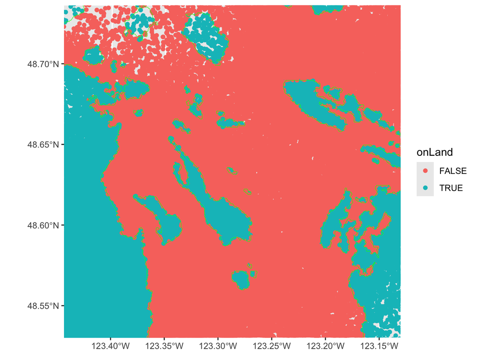

```r
border.size <- 10000
ggplot() +
  geom_sf(data = gulls.avail.sf, aes(color = onLand)) +
  geom_sf(data = land, col = "green", fill=NA) +
  xlim(st_bbox(xoxdel)[1]-border.size, st_bbox(xoxdel)[3]+border.size) +
  ylim(st_bbox(xoxdel)[2]-border.size, st_bbox(xoxdel)[4]+border.size)
```

Let’s also get distance to coastline (as gulls are coastal and do not go far inland or offshore). To calculate distance to coastline, we first need to make it a line.

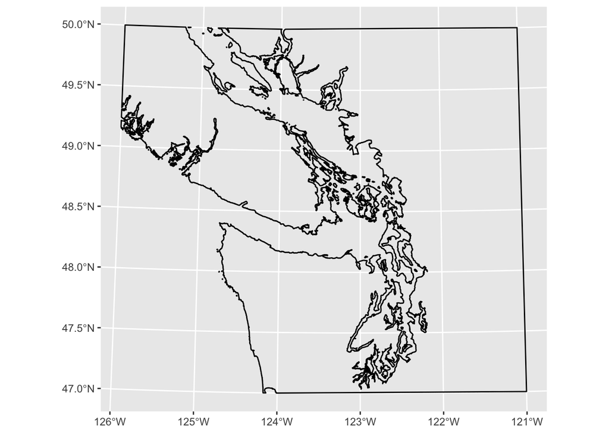

```r
land.1 <- st_cast(st_union(land),  to = 'MULTILINESTRING') # Make it a line
ggplot() +
  geom_sf(data=land.1)
```

Now calculate distance to land. This will take a few minutes to run.

```r
gulls.avail.sf$distShore <- as.numeric(st_distance(gulls.avail.sf, land.1))/1000 # in km
```

Gulls are central place foragers when they are nesting, so let’s also look at distance to colony.

```r
# change object to multi line string to be able to calculate distance
xoxdel.1 <- st_cast(st_union(xoxdel),  to = 'MULTILINESTRING') # Need to make it a line to
gulls.avail.sf$distXOXDEL <- as.numeric(st_distance(gulls.avail.sf, xoxdel.1))/1000 # in km
```

Correlation between human impact and distance to colony. Only considering land locations.

```r
cor(subset(gulls.avail.sf, onLand)$HumanImpact,
    subset(gulls.avail.sf, onLand)$distXOXDEL)
```

```
## [1] 0.1394644
```

Pretty low.

```r
all.steps <- as.data.frame(gulls.avail.sf)
# Numeric value so that it's a like a dummy variable
all.steps$onLandN <- as.numeric(all.steps$onLand)
```

## Fit models

Function to fit model.

```r
fit.poisson.rs <- function(formula, data, start = list(theta = log(1e6)),
                           map = list(theta = factor(NA))){
  ssf <- glmmTMB(formula, family = poisson,
                 data = data, start = start, map = map)
  return(ssf)
}
```

AICc table function.

```r
AICcTable <- function(m, ...){
  namesObj <- names(tibble::lst(m, ...))
  namesObj[1] <- deparse(substitute(m))
  AICc.table <- AICc(m, ...)
  row.names(AICc.table) <- namesObj
  AICc.table <- AICc.table %>% mutate(deltaAICc = AICc - min(AICc, na.rm = TRUE))
  AICc.table[order(AICc.table$deltaAICc), ]
}
```

We will explore two simple SSFs that focus on how land and human impact on land affect selection, while accounting for the fact that glaucous-winged gulls are coastal animals (there do not go far inland or offshore) and are central place foragers during incubation and chick rearing period. The baseline model only includes the relationship with land, human impact on land, distance to shore, and distance to colony, while the proxy-informed model includes an interaction with number of chicks.

Model 1 (baseline model): Chicks ignored

The model used to estimate the parameters of the baseline SSF models the step of individual $n$ at time $t$, $y_{n,t,j}$, which take the value of 1 for used step ($j = 0$) and 0 for control points ($j = 1, \ldots, J$), as:

$$\mu_{n,t,j} = \text{exp}(\beta_{0,n,t} +
\beta_{1,n} d_{n,t,j} + \beta_{2,n} c_{n,t,j} + \beta_{3,n} w_{n,t,j} +
\beta_{4,n} w_{n,t,j} z_{n,t,j} + \beta_{l} l_{n,t,j} +
\beta_{\text{ln}} \text{ln}(l_{n,t,j}) + \beta_{\theta}
\text{cos}(\theta_{n,t,j}))), \qquad y_{n,t,j} \sim
\text{Poisson}(\mu_{n,t,j}),$$

where for the $n^{th}$ individual at time $t$ for step $j$, $d_{n,t,j}$ is distance to shore, $c_{n,t,j}$ is the distance to colony, $w_{n,t,j}$ is whether the animal was on land (1) or not (0), $z_{n,t,j}$ is the cumulative human impact value. The coefficient $\beta_{0,n,t}$ is the step-specific intercept of animal $n$ at time $t$, which is modeled as a random effect $\beta_{0,n,t} \sim \text{N}(0,1000000^2)$, while the coefficients $\beta_{1,n}$, $\beta_{2,n}$, $\beta_{3,n}$, and $\beta_{4,n}$ are the coefficients associated with the relationship with covariates and are modelled with random effects where we estimate the mean and standard deviation: $\beta_{1,n} \sim \text{N}(\beta_1, \sigma_1^2)$, $\beta_{2,n} \sim \text{N}(\beta_2, \sigma_2^2)$, $\beta_{3,n} \sim \text{N}(\beta_3, \sigma_3^2)$, and $\beta_{4,n} \sim \text{N}(\beta_4, \sigma_4^2)$. The rest of the equation is associated with the movement kernel, where $l_{n,t,j}$ and $\theta_{n,t,j}$ are the step length and turning angle of step $j$ of individual $n$ at time $j$, and the coefficients $\beta_l$, $\beta_{\text{ln}}$, $\beta_{\theta}$.

Since the land variable, $w_{n,t,j}$ can only take two values: 0 and 1, it controls the fact that human impact is only included when the animal is on land.

This will take a few minutes to run.

```r
ssf.rsri <- fit.poisson.rs(formula = case_num ~ -1 +
                             distShore +
                             distXOXDEL +
                             onLandN +
                             I(onLandN*HumanImpact) +
                             sl_ + ln_sl + cos_ta + (1|step_id_) +
                             (0 +
                                distShore +
                                distXOXDEL +
                                onLandN +
                                I(onLandN*HumanImpact) | device_id),
                           data = all.steps,
                           start = list(theta = c(log(1e6), rep(0,10))),
                           map = list(theta=factor(c(NA,1,2,3,4, rep(NA,6)))))
summary(ssf.rsri)
```

```
##  Family: poisson  ( log )
## Formula:
## case_num ~ -1 + distShore + distXOXDEL + onLandN + I(onLandN *
##     HumanImpact) + sl_ + ln_sl + cos_ta + (1 | step_id_) + (0 +
##     distShore + distXOXDEL + onLandN + I(onLandN * HumanImpact) |
##     device_id)
## Data: data
##
##       AIC       BIC    logLik -2*log(L)  df.resid
##  522406.7  522533.0 -261192.4  522384.7    712658
##
## Random effects:
##
## Conditional model:
##  Groups    Name                     Variance  Std.Dev.  Corr
##  step_id_  (Intercept)              1.000e+12 1.000e+06
##  device_id distShore                2.252e-02 1.501e-01
##            distXOXDEL               4.528e-03 6.729e-02 0.00
##            onLandN                  5.026e-01 7.089e-01 0.00 0.00
##            I(onLandN * HumanImpact) 1.691e+00 1.300e+00 0.00 0.00 0.00
## Number of obs: 712669, groups:  step_id_, 13974; device_id, 12
##
## Conditional model:
##                            Estimate Std. Error z value Pr(>|z|)
## distShore                -1.726e-01  4.559e-02  -3.786 0.000153 ***
## distXOXDEL               -1.065e-01  2.024e-02  -5.261 1.44e-07 ***
## onLandN                   2.626e-01  2.142e-01   1.226 0.220147
## I(onLandN * HumanImpact) -5.086e-01  3.893e-01  -1.307 0.191347
## sl_                      -2.099e-05  4.278e-06  -4.907 9.27e-07 ***
## ln_sl                     5.480e-04  2.959e-03   0.185 0.853085
## cos_ta                   -2.844e-02  1.212e-02  -2.347 0.018940 *
## ---
## Signif. codes:  0 '***' 0.001 '**' 0.01 '*' 0.05 '.' 0.1 ' ' 1
```

There are many warning messages (not shown in compiled version), but these are common when fitting complex model to data. The fact that the standard errors are shown is a good sign. Let’s look if there are convergence issues.

```r
ssf.rsri$fit$convergence
```

```
## [1] 0
```

Looks ok.

Model 2 (proxy-informed model): includes number of chicks

The new model is based on the previous model but it includes interactions with the number of chicks.

$$\mu_{n,t,j} = \text{exp}(\beta_{0,n,t} +
\beta_{1,n} d_{n,t,j} + \beta_{2,n} c_{n,t,j} + \beta_{3,n} w_{n,t,j} +
\beta_{4,n} w_{n,t,j} z_{n,t,j} + \beta_{5} r_{n} c_{n,t,j} + \beta_{6}
r_{n} w_{n,t,j} z_{n,t,j} + \beta_{l} l_{n,t,j} + \beta_{\text{ln}}
\text{ln}(l_{n,t,j}) + \beta_{\theta} \text{cos}(\theta_{n,t,j}), \qquad
y_{n,t,j} \sim \text{Poisson}(\mu_{n,t,j}),$$

which differ from the model only in two terms: $\beta_{5} r_{n} c_{n,t,j}$ and $\beta_{6} r_{n} w_{n,t,j} z_{n,t,j}$, which both include an interaction with the number of chicks $r_{n}$.

This will take a few minutes to run.

```r
ssf.rsrifit <- fit.poisson.rs(formula =
                                case_num ~ -1 +
                                distShore +
                                distXOXDEL +
                                distXOXDEL:final_chick +
                                onLandN +
                                I(onLandN*HumanImpact) +
                                I(onLandN*HumanImpact):final_chick +
                                sl_ + ln_sl + cos_ta +
                                (1|step_id_) +
                                (0 +
                                   distShore +
                                   distXOXDEL +
                                   onLandN +
                                   I(onLandN*HumanImpact) | device_id),
                            data = all.steps,
                            start = list(theta = c(log(1e6), rep(0, 10))),
                            map =
                              list(theta =
                                     factor(c(NA,1,2,3,4,rep(NA, 6))))) # Set correlation 0
summary(ssf.rsrifit)
```

```
##  Family: poisson  ( log )
## Formula:
## case_num ~ -1 + distShore + distXOXDEL + distXOXDEL:final_chick +
##     onLandN + I(onLandN * HumanImpact) + I(onLandN * HumanImpact):final_chick +
##     sl_ + ln_sl + cos_ta + (1 | step_id_) + (0 + distShore +
##     distXOXDEL + onLandN + I(onLandN * HumanImpact) | device_id)
## Data: data
##
##       AIC       BIC    logLik -2*log(L)  df.resid
##  522397.4  522546.6 -261185.7  522371.4    712656
##
## Random effects:
##
## Conditional model:
##  Groups    Name                     Variance  Std.Dev.  Corr
##  step_id_  (Intercept)              1.000e+12 1.000e+06
##  device_id distShore                2.275e-02 1.508e-01
##            distXOXDEL               2.909e-03 5.393e-02 0.00
##            onLandN                  5.202e-01 7.212e-01 0.00 0.00
##            I(onLandN * HumanImpact) 7.957e-01 8.920e-01 0.00 0.00 0.00
## Number of obs: 712669, groups:  step_id_, 13974; device_id, 12
##
## Conditional model:
##                                        Estimate Std. Error z value Pr(>|z|)
## distShore                            -1.722e-01  4.579e-02  -3.761 0.000169 ***
## distXOXDEL                           -6.980e-02  2.197e-02  -3.177 0.001490 **
## onLandN                               2.639e-01  2.175e-01   1.214 0.224887
## I(onLandN * HumanImpact)              3.440e-01  3.678e-01   0.935 0.349625
## sl_                                  -2.114e-05  4.280e-06  -4.940 7.79e-07 ***
## ln_sl                                 5.733e-04  2.961e-03   0.194 0.846506
## cos_ta                               -2.843e-02  1.212e-02  -2.345 0.019018 *
## distXOXDEL:final_chick               -3.992e-02  1.620e-02  -2.464 0.013726 *
## final_chick:I(onLandN * HumanImpact) -9.272e-01  2.685e-01  -3.454 0.000553 ***
## ---
## Signif. codes:  0 '***' 0.001 '**' 0.01 '*' 0.05 '.' 0.1 ' ' 1
```

There may be warnings (not shown in compiled version), but these are common when fitting a complex glmm. The fact that we get standard errors is a good sign. Let’s look if there are convergence issues.

```r
ssf.rsrifit$fit$convergence
```

```
## [1] 0
```

Looks ok.

Look at AICc of the two models.

```r
AICcTable(ssf.rsrifit, ssf.rsri)
```

```
##             df     AICc deltaAICc
## ssf.rsrifit 13 522397.4  0.000000
## ssf.rsri    11 522406.7  9.349362
```

```r
title <- "Parameter estimates from the two gull SSFs. The parameter estimates, along with standard errors, are presented. A * indicates that the p-value comparing this parameter value to 0 is significant at the significance level of 0.05."

coef_map <- c("distShore" = "$\\beta_1: d_{n,t,j}$", # "Distance to shore",
              "distXOXDEL" = "$\\beta_2: c_{n,t,j}$", # Distance to colony
              "onLandN" = "$\\beta_3: w_{n,t,j}$", # "On land"
              "I(onLandN * HumanImpact)" =
                "$\\beta_4: w_{n,t,j} z_{n,t,j}$", #"On land X Human impact",

              # "Distance to colony X Chick"
              "distXOXDEL:final_chick" = "$\\beta_5: r_{n} c_{n,t,j}$",
              "final_chick:distXOXDEL" = "$\\beta_5: r_{n} c_{n,t,j}$",

              # "On land X Human impact X Chick"
              "I(onLandN * HumanImpact):final_chick" =
                "$\\beta_6: r_{n} w_{n,t,j} z_{n,t,j}$",
              "final_chick:I(onLandN * HumanImpact)" =
                "$\\beta_6: r_{n} w_{n,t,j} z_{n,t,j}$",

              "sl_" = "$\\beta_l: l_{n,t,j}$",
              "ln_sl" = "$\\beta_{\\text{ln}}: \\text{ln}(l_{n,t,j})$",
              "cos_ta" = "$\\beta_{\\theta}: \\text{cos}(\\theta_{n,t,j})$",

              #"SD(distance to shore), group: ID",
              "SD (distShore device_id)" = "$\\sigma_1: \\beta_1$",
              #"SD(distance to colony), group: ID",
              "SD (distXOXDEL device_id)" = "$\\sigma_2: \\beta_2$",
              #"SD(On land), group: ID",
              "SD (onLandN device_id)" = "$\\sigma_3: \\beta_3$",
              #"SD(On land X Human Impact), group: ID",
              "SD (I(onLandN * HumanImpact) device_id)" = "$\\sigma_4: \\beta_4$")

estimates <- "{estimate}{stars}"
statistics <-  "({std.error})"
```

```r
models <- list("Ignored" = ssf.rsri,
               "In selection function" = ssf.rsrifit)

modelsummary(models,
             estimate = estimates,
             statistic = statistics,
             coef_map = coef_map,
             gof_map = NA,
             fmt = fmt_significant(3),
             stars = c("*"=0.05),
             title = title,
             escape = FALSE) %>%
  add_header_above(c("Par: Variables" = 1, "Number of chicks" = 2),
                   escape = FALSE)
```

Parameter estimates from the two gull SSFs. The parameter estimates, along with standard errors, are presented. A * indicates that the p-value comparing this parameter value to 0 is significant at the significance level of 0.05.

| Par: Variables | Number of chicks Ignored | Number of chicks In selection function |
| --- | --- | --- |
| $\beta_1: d_{n,t,j}$ | −0.1726* | −0.1722* |
|  | (0.0456) | (0.0458) |
| $\beta_2: c_{n,t,j}$ | −0.1065* | −0.0698* |
|  | (0.0202) | (0.0220) |
| $\beta_3: w_{n,t,j}$ | 0.263 | 0.264 |
|  | (0.214) | (0.217) |
| $\beta_4: w_{n,t,j} z_{n,t,j}$ | −0.509 | 0.344 |
|  | (0.389) | (0.368) |
| $\beta_5: r_{n} c_{n,t,j}$ |  | −0.0399* |
|  |  | (0.0162) |
| $\beta_6: r_{n} w_{n,t,j} z_{n,t,j}$ |  | −0.927* |
|  |  | (0.268) |
| $\beta_l: l_{n,t,j}$ | −2.10e−05* | −2.11e−05* |
|  | (4.28e−06) | (4.28e−06) |
| $\beta_{\text{ln}}: \text{ln}(l_{n,t,j})$ | 0.000548 | 0.000573 |
|  | (0.002959) | (0.002961) |
| $\beta_{\theta}: \text{cos}(\theta_{n,t,j})$ | −0.0284* | −0.0284* |
|  | (0.0121) | (0.0121) |
| $\sigma_1: \beta_1$ | 0.15 | 0.151 |
| $\sigma_2: \beta_2$ | 0.0673 | 0.0539 |
| $\sigma_3: \beta_3$ | 0.709 | 0.721 |
| $\sigma_4: \beta_4$ | 1.3 | 0.892 |

```r
options(modelsummary_format_numeric_latex = "plain")
# To output for latex
table.latex <- modelsummary(models,
             estimate = estimates,
             statistic = statistics,
             coef_map = coef_map,
             gof_map = NA,
             fmt = fmt_significant(3),
             stars = c("*"=0.05),
             title = title,
             output = "gull_par_est.tex",
             escape = FALSE) %>%
  add_header_above(c("Par: Variables" = 1, "Number of chicks" = 2),
            escape = FALSE)
cat(table.latex, file="gull_par_est.tex")
```

How the selection function changes with chick number.

Function to be able to plot the effects.

```r
chick.ignored.col <- "black"

chick.3.col <- "#2c7bb6"
chick.2.col <- "#abd9e9"
chick.1.col <- "#fdae61"
chick.0.col <- "#d7191c"

hum.imp.val.avg <- all.steps %>% filter(case_num == 1 & onLandN) %>% pull(distShore) %>% mean
dist.shore.val.avg <- all.steps %>% filter(case_num == 1) %>% pull(distShore) %>% mean
dist.xoxdel.val.avg <- all.steps %>% filter(case_num == 1) %>% pull(distXOXDEL) %>% mean


ssf.pred.hum <- function(model, n.chick, hum.imp.val = 0, dist.shore.val = 0, dist.xoxdel.val = 2000){
  if(is.na(n.chick)){
    ssf.pred.c <- exp(
      summary(model)$coef$cond["distShore",1]*dist.shore.val +
        summary(model)$coef$cond["distXOXDEL",1]*dist.xoxdel.val +
        summary(model)$coef$cond["onLandN",1] +
        summary(model)$coef$cond["I(onLandN * HumanImpact)",1]*hum.imp.val)

  }else{
    ssf.pred.c <- exp(
      summary(model)$coef$cond["distShore",1]*dist.shore.val +
        summary(model)$coef$cond["distXOXDEL",1]*dist.xoxdel.val +
        summary(model)$coef$cond["onLandN",1] +
        summary(model)$coef$cond["I(onLandN * HumanImpact)",1]*hum.imp.val +
        # Interactions with number of chicks (name changes)
        n.chick*summary(model)$coef$cond["distXOXDEL:final_chick",1]*dist.xoxdel.val +
        n.chick*summary(model)$coef$cond["final_chick:I(onLandN * HumanImpact)",1]*hum.imp.val)
  }
  return(ssf.pred.c)
}
```

Let’s look at the relationship with human impact.

```r
hum.imp.seq <- seq(0, 1, by = 0.01)
ssf.pred.chick <- data.frame(human.imp = hum.imp.seq,
                             pred.ignored = ssf.pred.hum(ssf.rsri, NA,
                                                         hum.imp.seq,
                                                         dist.shore.val.avg,
                                                         dist.xoxdel.val.avg))
ssf.pred.chick$pred.0 <- ssf.pred.hum(ssf.rsrifit, 0,
                                      hum.imp.seq,
                                      dist.shore.val.avg,
                                      dist.xoxdel.val.avg)
ssf.pred.chick$pred.1 <- ssf.pred.hum(ssf.rsrifit, 1,
                                      hum.imp.seq,
                                      dist.shore.val.avg,
                                      dist.xoxdel.val.avg)
ssf.pred.chick$pred.2 <- ssf.pred.hum(ssf.rsrifit, 2,
                                      hum.imp.seq,
                                      dist.shore.val.avg,
                                      dist.xoxdel.val.avg)
ssf.pred.chick$pred.3 <- ssf.pred.hum(ssf.rsrifit, 3,
                                      hum.imp.seq,
                                      dist.shore.val.avg,
                                      dist.xoxdel.val.avg)
```

Plot set up, general.

```r
land.col <- NA #"floralwhite"#'beige'
water.col <- rgb(222, 235, 247, maxColorValue = 255)#"lightcyan2"#'lightblue1'
hum.min.col <- "#ffffcc"
hum.mid.col <- "#fd8d3c"
hum.max.col <- "#800026"

ssf.min.col <- "#ffffcc"
ssf.mid.col <- "#41b6c4"
ssf.max.col <- "#0c2c84"

legend.text.size <- 0.8

plot.mar.l <- c(0.5,0.2,0,0.2)

x.min.crop.l <- 150000
x.max.crop.l <- 70000
y.min.crop.l <- 230000
y.max.crop.l <- 100000
```

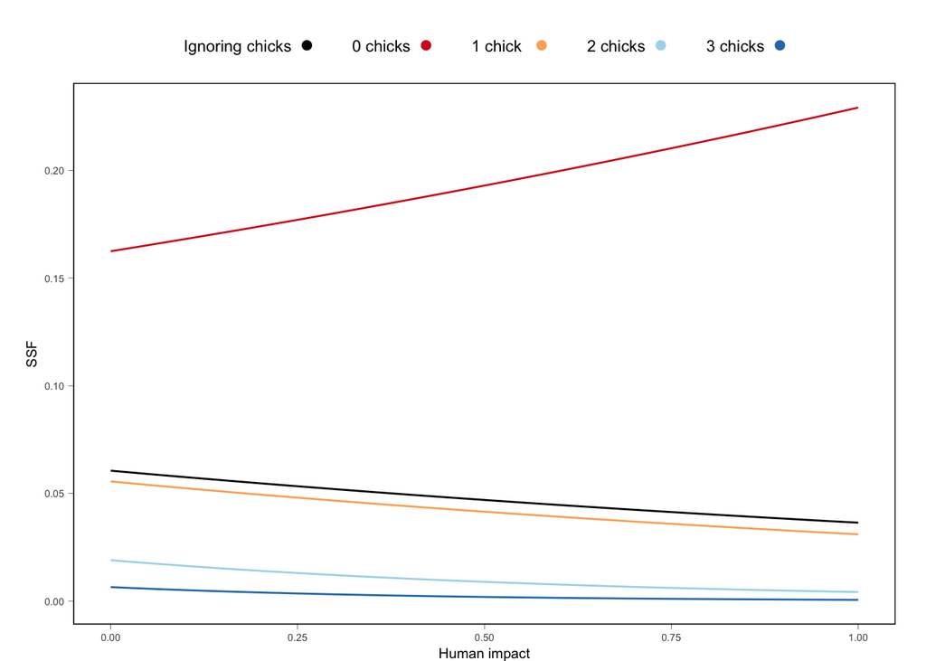

```r
hum.rel.chicks <- ggplot() +
  geom_line(data = ssf.pred.chick, aes(x = human.imp, y = pred.ignored),
            col=chick.ignored.col) +
  geom_line(data = ssf.pred.chick, aes(x = human.imp, y = pred.0), col=chick.0.col) +
  geom_line(data = ssf.pred.chick, aes(x = human.imp, y = pred.1), col=chick.1.col) +
  geom_line(data = ssf.pred.chick, aes(x = human.imp, y = pred.2), col=chick.2.col) +
  geom_line(data = ssf.pred.chick, aes(x = human.imp, y = pred.3), col=chick.3.col) +
  theme(panel.border = element_rect(fill=NA, linewidth = 0.5)) +
  xlab("Human impact") + ylab("SSF") +
  guides(Chicks.ignored = guide_custom(grid::circleGrob(r = unit(0.1, "cm"),
                                                  gp = grid::gpar(fill = chick.ignored.col,
                                                                  col=NA)),
                                 title = "Ignoring chicks", order = 1,
                                 theme = theme(legend.title =
                                                 element_text(size = rel(legend.text.size)),
                                               legend.position = "top")),
         Chick.0 = guide_custom(grid::circleGrob(r = unit(0.1, "cm"),
                                                  gp = grid::gpar(fill = chick.0.col,
                                                                  col=NA)),
                                 title = "0 chicks", order = 2,
                                 theme = theme(legend.title =
                                                 element_text(size = rel(legend.text.size)),
                                               legend.position = "top")),
         Chick.1 = guide_custom(grid::circleGrob(r = unit(0.1, "cm"),
                                                  gp = grid::gpar(fill = chick.1.col,
                                                                  col = NA)),
                                 title = "1 chick ", order = 3,
                                 theme = theme(legend.title =
                                                 element_text(
                                                   size = rel(legend.text.size)),
                                               legend.position = "top")),
         Chick.2 = guide_custom(grid::circleGrob(r = unit(0.1, "cm"),
                                                  gp = grid::gpar(fill = chick.2.col,
                                                                  col=NA)),
                                 title = "2 chicks", order = 4,
                                 theme = theme(legend.title =
                                                 element_text(
                                                   size = rel(legend.text.size)),
                                               legend.position = "top")),
         Chick.3 = guide_custom(grid::circleGrob(r = unit(0.1, "cm"),
                                                  gp = grid::gpar(fill = chick.3.col,
                                                                  col = NA)),
                                 title = "3 chicks", order = 5,
                                 theme = theme(legend.title =
                                                 element_text(
                                                   size = rel(legend.text.size)),
                                               legend.position = "top"))) +

    theme_classic() +
    theme(legend.position = "top",
          axis.title = element_text(size = rel(0.7)),
          axis.text = element_text(size = rel(0.5)),
          panel.border = element_rect(colour = "black", fill=NA, linewidth = 0.5),
          axis.line = element_line(colour = 'black', linewidth = 0.1),
          axis.ticks = element_line(colour = 'black', linewidth = 0.1),
          plot.margin = unit(c(1.05, 1.15, 0, 1), 'lines'))

hum.rel.chicks
```

```r
legend.plot.rel.hum <- as_ggplot(get_legend(hum.rel.chicks))
```

Create rasters for maps. Start with land raster. Put 0 on NAs for human, which are locations in water. The locations are already ignored since human impact is only switched on when on land.

```r
landR <- as.numeric(rasterize(land, human))
landR[is.na(landR)] <- 0
```

```r
hum.val.range <- range(as.data.frame(human))
human.4.map <- human
human.4.map[landR == 0] <- NA
```

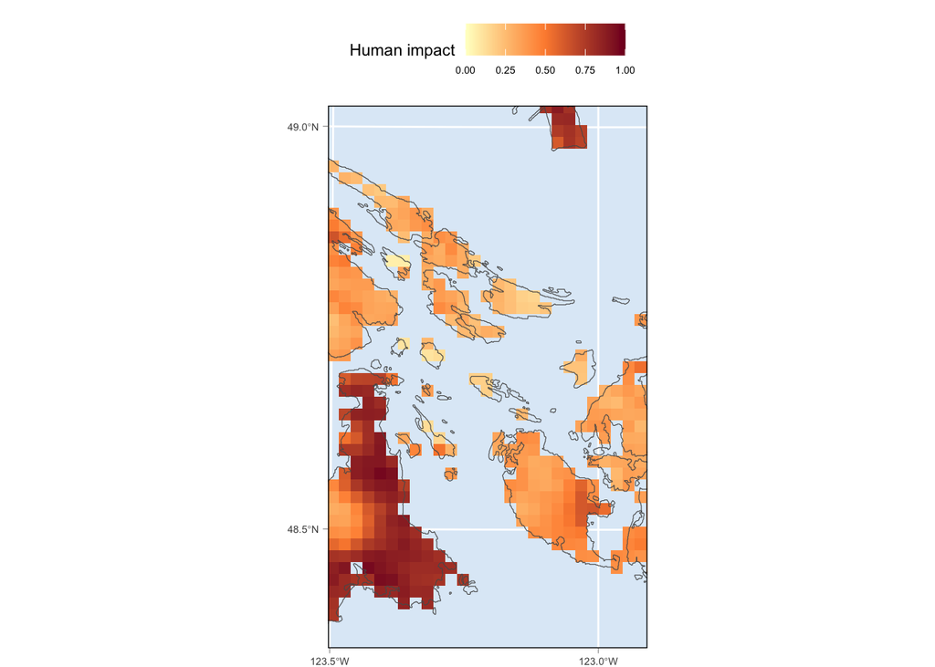

```r
hum.imp.map <- ggplot() +
    geom_spatraster(data = human.4.map) +
    scale_fill_gradient2(low=hum.min.col, mid=hum.mid.col, high=hum.max.col,
                      midpoint = mean(hum.val.range),
                      limit = hum.val.range, na.value = NA) +
    geom_sf(data=land, fill=land.col) +
    coord_sf(xlim = c(st_bbox(human)[1] + x.min.crop.l,
                      st_bbox(human)[3])-x.max.crop.l,
           ylim = c(st_bbox(human)[2]+y.min.crop.l,
                    st_bbox(human)[4])-y.max.crop.l, expand = FALSE) +
        theme(panel.background = element_rect(fill = water.col),
              panel.border = element_rect(colour = "black", fill = NA, linewidth = 0.5),
          legend.title = element_text(size = rel(legend.text.size)),
          legend.text = element_text(size = rel(0.5)),
          legend.position = "top",
          axis.text = element_text(size = rel(0.5)),
          axis.ticks = element_line(colour = 'black', linewidth = 0.1)) +
    scale_y_continuous(breaks = seq(47, 50, by = 0.5)) +
    scale_x_continuous(breaks = seq(-125, -120, by = 0.5)) +
    guides(fill = guide_colorbar(title = "Human impact", order = 4,
                                 theme = theme(legend.title =
                                                 element_text(
                                                   size = rel(legend.text.size)),
                                               legend.position = "top"))) +
    theme(plot.margin = unit(plot.mar.l, 'lines'))
hum.imp.map
```

Human impact legend.

```r
legend.human.map <- as_ggplot(get_legend(hum.imp.map))
```

Make NAs 0 for the predictions.

```r
human[is.na(human)] <- 0
```

Distance to shore raster.

```r
shore <- distance(landR, vect(land.1))/1000
```

Distance to colony raster.

```r
colony <- distance(landR, vect(xoxdel.1))/1000
```

Predictions for each chick category. First define function.

```r
ssf.map.pred <- function(model, n.chick){
  if(is.na(n.chick)){
    ssf.pred <- exp(
      summary(model)$coef$cond["distShore",1]*shore +
        summary(model)$coef$cond["distXOXDEL",1]*colony +
        summary(model)$coef$cond["onLandN",1]*landR +
        summary(model)$coef$cond["I(onLandN * HumanImpact)",1]*landR*human)
  }else{
    ssf.pred <- exp(
      summary(model)$coef$cond["distShore",1]*shore +
        summary(model)$coef$cond["distXOXDEL",1]*colony +
        summary(model)$coef$cond["onLandN",1]*landR +
        summary(model)$coef$cond["I(onLandN * HumanImpact)",1]*landR*human +
        summary(model)$coef$cond["distXOXDEL:final_chick",1]*colony*n.chick +
        summary(model)$coef$cond["final_chick:I(onLandN * HumanImpact)",1]*landR*human*n.chick
      )
    }

  return(ssf.pred)
}
```

```r
ssf.map.chick.ignored <- ssf.map.pred(ssf.rsri, NA)
ssf.map.chick.0 <- ssf.map.pred(ssf.rsrifit, 0)
ssf.map.chick.1 <- ssf.map.pred(ssf.rsrifit, 1)
ssf.map.chick.2 <- ssf.map.pred(ssf.rsrifit, 2)
ssf.map.chick.3 <- ssf.map.pred(ssf.rsrifit, 3)


ssf.maps <- rast(list(chicks.ignored = ssf.map.chick.ignored,
                      chick.0 = ssf.map.chick.0,
                      chick.1 = ssf.map.chick.1,
                      chick.2 = ssf.map.chick.2,
                      chick.3 = ssf.map.chick.3))
```

For now focus on land, since focus on human impact. So add NA to water.

```r
ssf.maps[landR == 0] <- NA
```

```r
# For common color bar
range(as.data.frame(ssf.maps))
```

```
## [1] 1.778146e-18 1.128769e+00
```

```r
val.range <- range(as.data.frame(ssf.maps))
# function for maps
mapping <- function(model.name, col.box  = "black", plot.mar = plot.mar.l,
                    x.min.crop = x.min.crop.l, x.max.crop = x.max.crop.l,
                    y.min.crop = y.min.crop.l, y.max.crop = y.max.crop.l){
  map <- ggplot() +
    geom_spatraster(data = ssf.maps[[model.name]]) +
    scale_fill_gradient2(low=ssf.min.col, mid=ssf.mid.col, high=ssf.max.col,
                      midpoint = mean(val.range), limit = val.range, na.value = NA) +
    geom_sf(data=land, fill=land.col) +
    coord_sf(xlim = c(st_bbox(ssf.maps[[model.name]])[1]+x.min.crop,
                      st_bbox(ssf.maps[[model.name]])[3])-x.max.crop,
           ylim = c(st_bbox(ssf.maps[[model.name]])[2]+y.min.crop,
                    st_bbox(ssf.maps[[model.name]])[4])-y.max.crop, expand = FALSE) +

        theme(panel.background = element_rect(fill = water.col),
              panel.border = element_rect(colour = col.box, fill=NA, linewidth = 0.5),
          legend.title = element_text(size = rel(legend.text.size)),
          legend.text = element_text(size = rel(0.5)),
          legend.position = "top",
          axis.text = element_text(size = rel(0.5)),
          axis.ticks = element_line(colour = 'black', linewidth = 0.1)) +
    scale_y_continuous(breaks = seq(47, 50, by =0.5)) +
    scale_x_continuous(breaks = seq(-125, -120, by = 0.5)) +
    guides(fill = guide_colorbar(title = "SSF", order = 4,
                                 theme = theme(legend.title =
                                                 element_text(size = rel(legend.text.size)),
                                               legend.position = "top"))) +
    theme(plot.margin = unit(plot.mar.l, 'lines'))
  return(map)
}
```

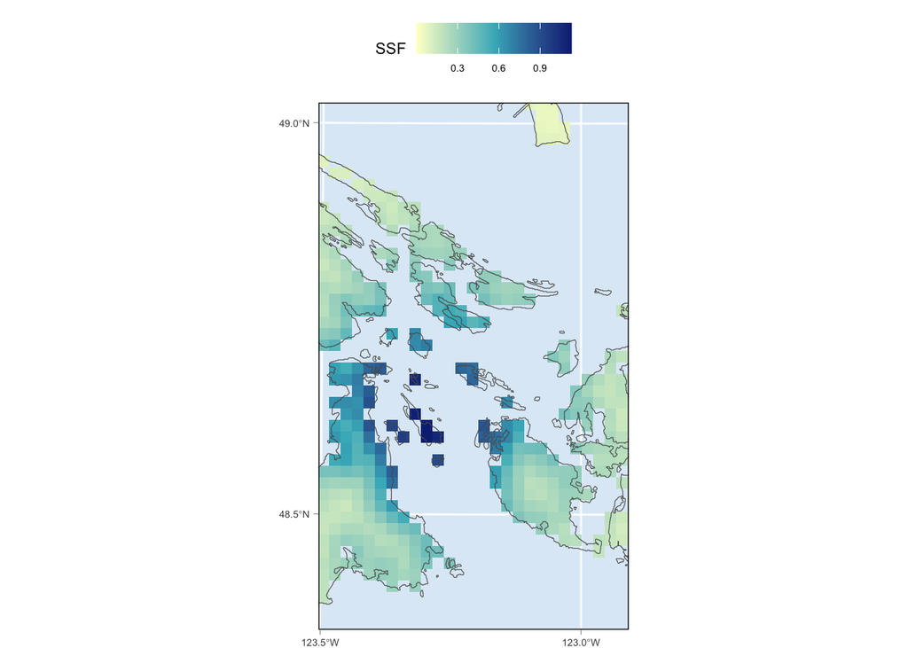

```r
mapping("chick.0", plot.mar = c(0.5,1,0,1))
```

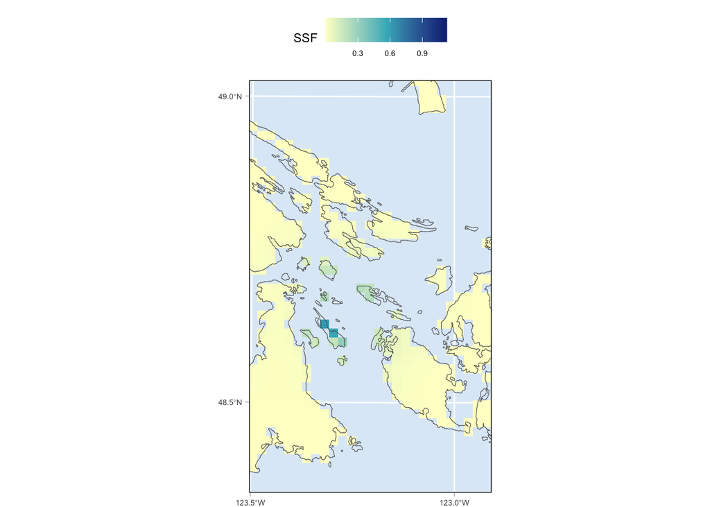

```r
mapping("chick.3", plot.mar = c(1,1,0,1))
```

```r
map.chicks.ignored <- mapping(model.name = "chicks.ignored")
map.chick.0 <- mapping(model.name = "chick.0", col.box  = chick.0.col)
map.chick.1 <- mapping(model.name = "chick.1", col.box  = chick.1.col)
map.chick.2 <- mapping(model.name = "chick.2", col.box  = chick.2.col)
map.chick.3 <- mapping(model.name = "chick.3", col.box  = chick.3.col)
```

Create legend for maps.

```r
legend.plot.map <- as_ggplot(get_legend(mapping(model.name = "chicks.ignored")))
```

## Final figure

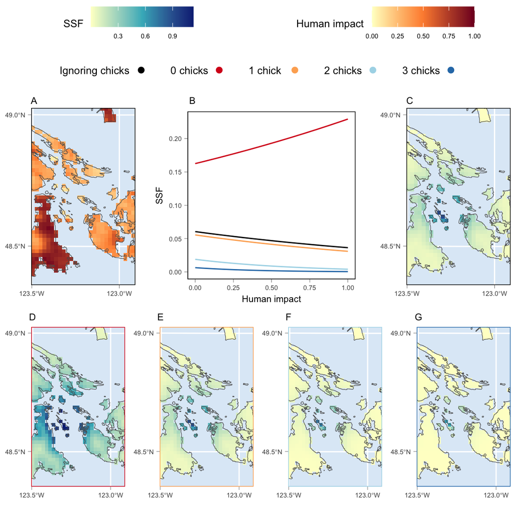

```r
ggarrange(ggarrange(ggarrange(legend.plot.map, legend.human.map, nrow=1),
                    legend.plot.rel.hum,
                    nrow=2, widths = c(0.7, 0.5)),
          ggarrange(
            ggarrange(hum.imp.map, hum.rel.chicks, map.chicks.ignored, legend = "none",
                     labels = c("A", "B", "C"), label.x = rep(0.2,3), label.y = rep(1, 3),
                     widths = c(0.27,0.46,0.27),
                     font.label = list(size = 8, face="plain"),
                     nrow = 1, ncol = 3),
            ggarrange(map.chick.0, map.chick.1, map.chick.2, map.chick.3, legend = "none",
                     labels = c("D", "E", "F", "G"),
                     label.x = rep(0.2,4), label.y = rep(0.97, 4),
                     font.label = list(size = 8, face="plain"),
                     nrow = 1, ncol = 4),
          nrow = 2, ncol = 1),
          nrow = 2, heights = c(0.2,0.9))
```

# Literature cited

Mu H., Li X., Wen Y., Huang J., Du P., Su W., Miao S., & Geng M. (2021). An annual global terrestrial Human Footprint dataset from 2000 to 2018. figshare. Figure. https://doi.org/10.6084/m9.figshare.16571064.v7

Mu H., Li X., Wen Y., Huang J., Du P., Su W., Miao S., & Geng, M. (2022). A global record of annual terrestrial human footprint dataset from 2000 to 2018. Scientific Data, 9, 176.